# Modeling Depth with Ordinary Least Squares

The aim of this analysis is to predict Depth using local and coda magnitudes. Additionally, because we seek the simplest model with the best predictive power, we would like to determine the correlation between Mc1 and Mc2. If these two quantities are highly collinear, we’d like to find which serves as a better predictor of depth.

First I load the test and train data sets and fit an ordinary least squares (OLS) model using ML and Mc2. The model coefficients are reported. I compare the root mean squared error (RMSE) from this model with that of a model using ML and Mc1. This serves to determine the relative predictive power of the quantities Mc1 and Mc2. Additionally, I compare the RMSE for a model which specifies the relationship between depth, ML, and the preferred coda magnitude to be depth = (+1)ML + (-1)Mc.

```r
#loading libraries and reading in data

library(readr)
library(Metrics)
library(ggplot2)

input.train.file = "C:/Users/riley/Seismo_Direc/cleaned_training_df.csv"
input.test.file = "C:/Users/riley/Seismo_Direc/cleaned_testing_df.csv"

train <- read_csv(input.train.file)
test <- read_csv(input.test.file)
```

```r
#investigating collinearity between Mc1 and Mc2
print(cor(train$Mc1, train$Mc2))
```

```
[1] 0.9864585
```

The correlation coefficient between Mc1 and Mc2 is 0.986. This indicates that these features are highly collinear, and are thus redundant as predictors. Further analysis explores which coda magnitude performs better in an OLS model

Model Fitting

```r
 #fit an OLS model for ML and Mc2
  model_mlmc2 <- lm(Dep ~ ML + Mc2, data = train)

  #evaluate OLS for ML and Mc2
  pred_mlmc2 <- predict(model_mlmc2, newdata = test)
  rmse_mlmc2 <- rmse(test$Dep, pred_mlmc2)
  print("RMSE for Dep ~ ML + Mc2:")
```

```
[1] "RMSE for Dep ~ ML + Mc2:"
```

```r
  print(rmse_mlmc2)
```

```
[1] 3.825135
```

```r
  print("Coefficients for Dep ~ ML + Mc2:")
```

```
[1] "Coefficients for Dep ~ ML + Mc2:"
```

```r
  print(model_mlmc2$coefficients)
```

```
(Intercept)          ML         Mc2
   9.717441    3.765668   -4.573735
```

The RMSE for this model is 3.825. The coefficients for ML and Mc2 are 3.766 and -4.574, respectively, with an intercept (or bias) of 9.717. We can interpret this to mean that for every one-unit (km, in our case) increase in depth, there is a corresponding increase in ML and decrease in Mc2.

```r
#fit an ols for ML and Mc1
  model_mlmc1 <- lm(Dep ~ ML + Mc1, data = train)

  #get RMSE
  pred_mlmc1 <- predict(model_mlmc1, newdata = test)
  rmse_mlmc1 <- rmse(test$Dep, pred_mlmc1)
  print("RMSE for Dep ~ ML + Mc1:")
```

```
[1] "RMSE for Dep ~ ML + Mc1:"
```

```r
  print(rmse_mlmc1)
```

```
[1] 3.847081
```

```r
  print("Coefficients for Dep ~ ML + Mc1:")
```

```
[1] "Coefficients for Dep ~ ML + Mc1:"
```

```r
  print(model_mlmc1$coefficients)
```

```
(Intercept)          ML         Mc1
  10.486760    3.197836   -4.310201
```

The RMSE for this model is 3.847, slightly higher than for the previous model using Mc2. The coefficients for ML and Mc1 are 3.198 and -4.310, respectively, with an intercept (or bias) of 10.487. We can interpret this to mean that for every one-unit increase in depth, there is a corresponding increase in ML and decrease in Mc1.

```r
#fit an ordinary least squares for ML and Mc2 where we specify coefficients of +1 and -1 respectively.

  bias <- mean(train$Dep - (train$ML - train$Mc2))
  print("Bias for Dep ~ (1)ML + (-1)Mc2:")
```

```
[1] "Bias for Dep ~ (1)ML + (-1)Mc2:"
```

```r
  print(bias)
```

```
[1] 8.890413
```

```r
  y_test <- (test$ML - test$Mc2) + bias

  print("RMSE for Dep ~ (1)ML + (-1)Mc2:")
```

```
[1] "RMSE for Dep ~ (1)ML + (-1)Mc2:"
```

```r
  print(rmse(test$Dep, y_test))
```

```
[1] 3.774341
```

The RMSE for this model is 3.774, slightly lower than for the previous models. Additionally, the bias is 8.890 when the coefficients for ML and Mc2 are 1 and -1, respectively.

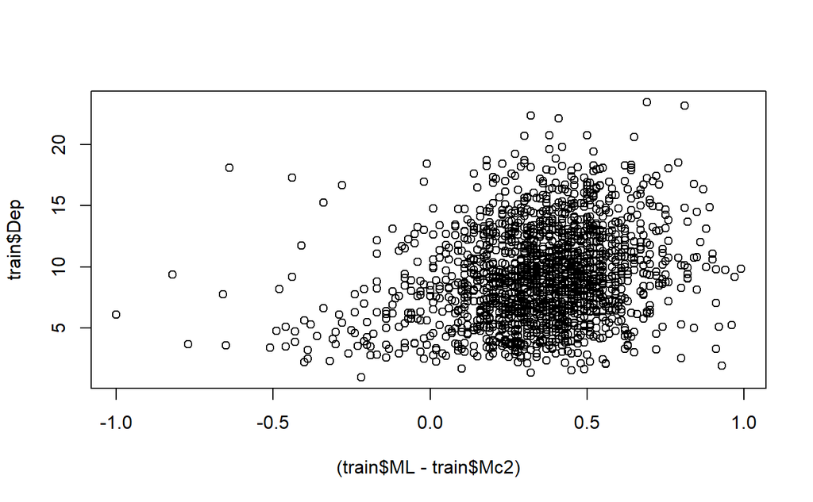

```r
#We can plot the training residuals and observe the correlation between residuals and depth.
 plot((train$ML - train$Mc2), train$Dep)
```

```r
#Save the test residuals
test$resids <- test$Dep - y_test

write.csv(test$resids,file="C:/Users/riley/ds_portfolio/ml_min_mc_resids.csv", row.names=TRUE)
```